# Verifying TOSTER’s *F*-test Equivalence Procedure

- Show All Code
- Hide All Code
- View Source

A reproduction of the simulation study in Campbell & Lakens (2021)

Author

Aaron R. Caldwell

Published

September 5, 2026

```r
library(TOSTER)
library(ggplot2)
library(dplyr)
library(tidyr)
library(knitr)

theme_set(theme_bw(base_size = 12))
set.seed(123)
```

## Purpose

@Campbell_2021 proposed an omnibus non-inferiority (“equivalence”) test for $R^2$ in multivariable linear regression and for the omnibus effect in a one-way ANOVA, and evaluated its operating characteristics by simulation. `TOSTER::equ_ftest()` implements a generalization of that procedure.

This document does three things:

1. Establishes that TOSTER’s non-centrality parameter is **algebraically identical** to the published one in the setting Campbell & Lakens studied, and confirms this numerically.
2. **Reproduces their simulation study** using TOSTER’s implementation, and checks that the recovered operating characteristics match what the paper reports.
3. Notes a few things about the published supplementary code that are worth knowing if anyone tries to run it directly.

This is a verification exercise. Nothing here is currently cited in the manuscript.

**NoteSummary of findings**

- TOSTER’s non-centrality parameter reduces **exactly** to the published expression whenever $df_1 + df_2 + 1 = N$, which holds for both the one-way ANOVA and the multivariable regression settings Campbell & Lakens simulated. Numerical agreement is at machine precision (max absolute difference $\approx 2 \times 10^{-16}$).
- The reproduced simulation recovers the published behaviour: the rejection rate is at or below $\alpha$ everywhere the null hypothesis is true, and rises to exactly $\alpha$ at the boundary $\Delta = \rho^2$.
- `power_eq_f()` reproduces the analytic power function used in their supplement **exactly** (difference of 0 across every combination checked).

Part 2 goes beyond what Campbell & Lakens simulated, into the designs where $df_1 + df_2 + 1 \neq N$:

- **The generalization holds its size.** Across one-way repeated measures (48 cells), factorial between-subjects (108), and the between-subjects effect of a mixed design (8), the rejection rate at the null boundary is 0.0504, 0.0501 and 0.0505 against a nominal 0.05. `equ_anova()`’s degrees-of-freedom extraction agrees with the closed form exactly.
- **$df_1 + df_2 + 1$ is the effective sample size of the error stratum**, not an approximation to total N. The mixed design shows this cleanly: there the correct normalizer is the *subject count*, far smaller than the observation count.
- **In repeated-measures designs the bound is not a share of total variance.** Calibrated against total variance instead of the partial scale, the test becomes severely conservative — rejecting at 0.022 rather than 0.05 when $k = 2$ — and more so as $n$ grows. An interpretation trap, not a bug.
- **Sphericity is the one real limitation.** `equ_anova()` silently ignores Greenhouse-Geisser and Huynh-Feldt corrections, and at Box’s $\epsilon = 0.5$ the size reaches 0.19 — nearly four times nominal — or collapses to 0.02, depending on where the effect sits in the contrast space.

# Part 1: Reproducing the published simulation

## Background: the procedure

The hypotheses are one-sided, because a proportion of variance cannot be negative:

$$H_0: \rho^2 \geq \Delta \qquad \text{versus} \qquad H_1: \rho^2 < \Delta$$

@Campbell_2021 give the *p*-value for a model with $K$ predictors and $N$ observations as

$$p = p_F\left(F; \space K, \space N - K - 1, \space \frac{N \cdot \Delta}{1 - \Delta}\right)$$

where $p_F(\cdot)$ is the CDF of the non-central *F* distribution. TOSTER instead computes the non-centrality parameter from the degrees of freedom directly, so that the same logic can be applied to designs where the relationship between $N$ and the degrees of freedom is less direct:

$$\lambda_{eq} = \frac{\Delta}{1 - \Delta} \cdot (df_1 + df_2 + 1)$$

### The two are identical in this setting

For a regression with $K$ predictors, $df_1 = K$ and $df_2 = N - K - 1$, so

$$df_1 + df_2 + 1 = K + (N - K - 1) + 1 = N$$

and the two expressions coincide. The same holds for a one-way ANOVA with $J$ groups, where $df_1 = J - 1$ and $df_2 = N - J$. Any divergence between the two implementations is therefore floating-point noise, not a difference in method.

```r
grid <- expand.grid(
  Fstat = c(0.5, 1.2, 3.4, 8.9),
  K     = c(2, 4, 5),
  N     = c(60, 180, 450, 1000),
  Delta = c(0.01, 0.035, 0.06, 0.10)
)
grid$df1 <- grid$K
grid$df2 <- grid$N - grid$K - 1

# Campbell & Lakens, verbatim from their supplementary script
grid$p_CL <- pf(grid$Fstat,
                df1 = grid$df1, df2 = grid$df2,
                ncp = (grid$N * grid$Delta) / (1 - grid$Delta),
                lower.tail = TRUE)

# TOSTER
grid$p_TOSTER <- mapply(
  function(f, d1, d2, e) equ_ftest(Fstat = f, df1 = d1, df2 = d2, eqb = e)$p.value,
  grid$Fstat, grid$df1, grid$df2, grid$Delta
)

c(comparisons     = nrow(grid),
  max_abs_diff    = max(abs(grid$p_CL - grid$p_TOSTER)),
  machine_epsilon = .Machine$double.eps)
```

```
    comparisons    max_abs_diff machine_epsilon
   1.920000e+02    2.220446e-16    2.220446e-16
```

Agreement is at machine precision across all 192 combinations.

## The simulation design

The design below follows `disregard_simulation_study_2.R` from the published supplement, which is the more complete of the two scripts (it adds a true-null condition and overlays the analytic power curve).

| Factor | Levels |
| --- | --- |
| Predictors $K$ | 2, 4 |
| Sample size $N$ | 60, 180, 450, 1000 |
| Residual variance $\sigma^2$ | 0.4, 0.5, 1 (effect present); 1 with $\beta = 0$ (true null) |
| Equivalence bound $\Delta$ | 0.010 to 0.100 in steps of 0.005 |
| Replications | 10,000 per cell |

Predictors are balanced binary variables from a $2^4$ factorial grid. Coefficients are $\beta = (0.2,\ 0.3)$ for $K = 2$ and $\beta = (0.2,\ 0.2,\ -0.1,\ -0.2)$ for $K = 4$. Both give $\sum \beta_j^2 = 0.13$, so the two values of $K$ produce the same true $\rho^2$ at a given $\sigma^2$ — an elegant feature of their design that makes the two facets directly comparable.

### The true $\rho^2$

Campbell & Lakens estimate the true $\rho^2$ by Monte Carlo over a 32-million-row design matrix. It is available in closed form. Because the predictors are independent Bernoulli(0.5), $\mathrm{Var}(X\beta) = 0.25 \sum \beta_j^2 = 0.0325$, giving $\rho^2 = 0.0325 / (0.0325 + \sigma^2)$.

One wrinkle is worth handling carefully. Their code builds the design with `X[1:N, ]`, taking the first $N$ rows of a repeating 16-row block. Since none of $N \in \{60, 180, 450, 1000\}$ is a multiple of 16, the final block is truncated and the four predictors are not perfectly balanced. The quantity that actually determines whether $H_0$ holds is therefore the **design-specific** $\rho^2$, computed from the non-centrality the fixed design implies:

$$\lambda_{\text{true}} = \frac{\lVert (I - P_1) X\beta \rVert^2}{\sigma^2},
\qquad
\rho^2_{\text{true}} = \frac{\lambda_{\text{true}}}{\lambda_{\text{true}} + N}$$

```r
build_X <- function(K, N) {
  base <- as.matrix(expand.grid(X1 = c(0, 1), X2 = c(0, 1),
                                X3 = c(0, 1), X4 = c(0, 1)))
  reps <- ceiling(N / nrow(base))
  Xf   <- cbind(1, base[rep(seq_len(nrow(base)), reps), , drop = FALSE])
  Xf[seq_len(N), c(1, seq_len(K) + 1), drop = FALSE]
}

beta_for <- function(K, null = FALSE) {
  if (null) return(rep(0, K + 1))
  if (K == 2) c(0, 0.2, 0.3) else c(0, 0.2, 0.2, -0.1, -0.2)
}

rho2_design <- function(K, N, sigma2, betavec) {
  mu     <- as.vector(build_X(K, N) %*% betavec)
  lambda <- sum((mu - mean(mu))^2) / sigma2
  lambda / (lambda + N)
}
```

```r
expand.grid(K = c(2, 4), N = c(60, 180, 450, 1000), sigma2 = c(0.4, 0.5, 1)) |>
  rowwise() |>
  mutate(
    rho2_population = 0.0325 / (0.0325 + sigma2),
    rho2_design     = rho2_design(K, N, sigma2, beta_for(K))
  ) |>
  ungroup() |>
  mutate(across(starts_with("rho2"), ~ round(.x, 5))) |>
  pivot_wider(names_from = N, values_from = rho2_design,
              names_prefix = "N = ") |>
  kable(caption = "Population vs. design-specific true rho-squared. The K = 2 design stays balanced under truncation; K = 4 drifts slightly.")
```

Population vs. design-specific true rho-squared. The K = 2 design stays balanced under truncation; K = 4 drifts slightly.

| K | sigma2 | rho2_population | N = 60 | N = 180 | N = 450 | N = 1000 |
| --- | --- | --- | --- | --- | --- | --- |
| 2 | 0.4 | 0.07514 | 0.07514 | 0.07514 | 0.07514 | 0.07514 |
| 4 | 0.4 | 0.07514 | 0.07350 | 0.07560 | 0.07495 | 0.07514 |
| 2 | 0.5 | 0.06103 | 0.06103 | 0.06103 | 0.06103 | 0.06103 |
| 4 | 0.5 | 0.06103 | 0.05968 | 0.06140 | 0.06088 | 0.06103 |
| 2 | 1.0 | 0.03148 | 0.03148 | 0.03148 | 0.03148 | 0.03148 |
| 4 | 1.0 | 0.03148 | 0.03076 | 0.03167 | 0.03139 | 0.03148 |

The $K = 2$ design happens to remain balanced under truncation (the first two columns of the factorial grid cycle with periods 2 and 4). The $K = 4$ design drifts by up to about 0.002 in $\rho^2$. This is minor, but it is the reason the boundary check below uses the design-specific value rather than the population value.

## Reproducing the simulation

The implementation below is a vectorized rewrite rather than a transcription. For a fixed design matrix the QR decomposition can be reused across all replications, so the whole study runs in well under a minute instead of fitting 320,000 separate models with `lm()`. The statistic computed is identical.

```r
sim_condition <- function(K, N, sigma2, betavec, Deltavec,
                          nSim = 10000, alpha = 0.05, block = 2500) {
  X   <- build_X(K, N)
  mu  <- as.vector(X %*% betavec)
  qrX <- qr(X)
  df2 <- N - K - 1

  Fstats <- numeric(nSim)
  done <- 0L
  while (done < nSim) {
    b   <- min(block, nSim - done)
    Y   <- mu + matrix(rnorm(N * b, 0, sqrt(sigma2)), nrow = N)
    RSS <- colSums(qr.resid(qrX, Y)^2)
    TSS <- colSums(sweep(Y, 2, colMeans(Y))^2)
    R2  <- 1 - RSS / TSS
    Fstats[(done + 1):(done + b)] <- (R2 / K) / ((1 - R2) / df2)
    done <- done + b
  }

  data.frame(
    Delta = Deltavec,
    pr_reject = vapply(Deltavec, function(D) {
      mean(pf(Fstats, K, df2, ncp = N * D / (1 - D), lower.tail = TRUE) < alpha)
    }, numeric(1))
  )
}
```

```r
Deltavec <- seq(0.01, 0.10, 0.005)
nSim     <- 10000

conditions <- expand.grid(
  K       = c(2, 4),
  N       = c(60, 180, 450, 1000),
  sigma2  = c(0.4, 0.5, 1),
  is_null = c(FALSE, TRUE),
  stringsAsFactors = FALSE
) |>
  # the true-null condition is defined only once, at sigma2 = 1
  filter(!(is_null & sigma2 != 1))

set.seed(123)
results <- conditions |>
  rowwise() |>
  group_split() |>
  lapply(function(cond) {
    b <- beta_for(cond$K, null = cond$is_null)
    out <- sim_condition(cond$K, cond$N, cond$sigma2, b, Deltavec, nSim = nSim)
    out$K       <- cond$K
    out$N       <- cond$N
    out$sigma2  <- cond$sigma2
    out$is_null <- cond$is_null
    out$rho2    <- if (cond$is_null) 0 else rho2_design(cond$K, cond$N, cond$sigma2, b)
    out
  }) |>
  bind_rows()

results <- results |>
  mutate(
    rho2_lab = factor(round(rho2, 3)),
    N_lab    = factor(N, levels = c(60, 180, 450, 1000)),
    K_lab    = factor(K, levels = c(2, 4), labels = c("K = 2", "K = 4")),
    grp      = interaction(rho2_lab, N_lab, drop = TRUE)
  )

dim(results)
```

```
[1] 608  11
```

### Figure 1: rejection rate, truncated axis

This is their main figure. The horizontal line is $\alpha = 0.05$; the vertical dashed lines mark each true $\rho^2$. **To the left of a vertical line, $H_0$ is true**, and the curve of the matching colour must sit at or below 0.05.

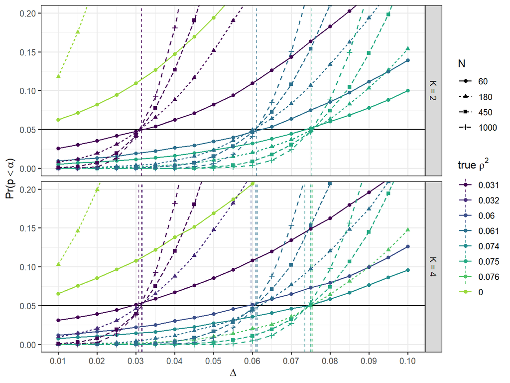

Figure 1: Probability of rejecting the equivalence null as a function of the bound. Colour distinguishes the true rho-squared; point shape and line type distinguish sample size. Vertical dashed lines mark each true rho-squared, i.e. the boundary of the null hypothesis.

```r
bounds <- results |> distinct(K_lab, rho2, rho2_lab) |> filter(rho2 > 0)

ggplot(results, aes(x = Delta, y = pr_reject,
                    group = grp, colour = rho2_lab)) +
  geom_vline(data = bounds, aes(xintercept = rho2, colour = rho2_lab),
             linetype = "dashed", linewidth = 0.4, alpha = 0.7) +
  geom_hline(yintercept = 0.05, linewidth = 0.4) +
  geom_line(aes(linetype = N_lab)) +
  geom_point(aes(shape = N_lab), size = 1.6) +
  facet_grid(K_lab ~ .) +
  scale_x_continuous(breaks = seq(0, 0.10, by = 0.01)) +
  scale_y_continuous(breaks = seq(0, 0.20, by = 0.05)) +
  coord_cartesian(ylim = c(0, 0.20)) +
  scale_colour_viridis_d(end = 0.85) +
  labs(x = expression(Delta),
       y = expression("Pr(" * p < alpha * ")"),
       colour = expression("true " * rho^2),
       shape = "N", linetype = "N")
```

### Figure 2: rejection rate, full axis

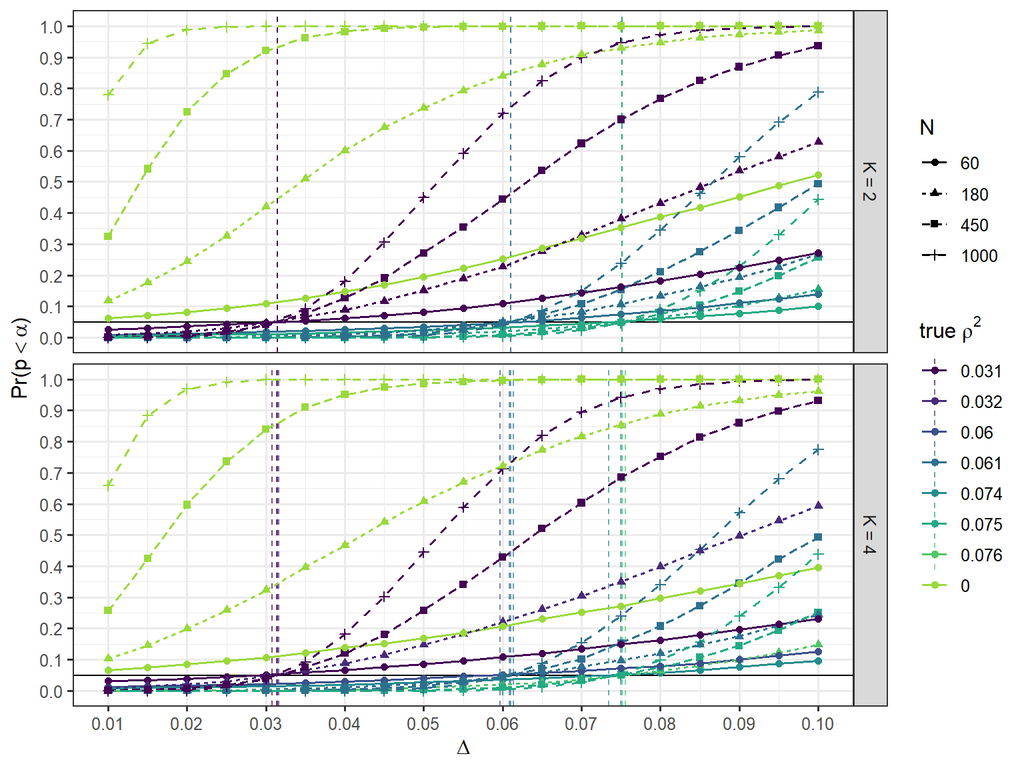

Figure 2: The same simulation on the full vertical scale, showing how power accumulates once the bound exceeds the true rho-squared.

```r
ggplot(results, aes(x = Delta, y = pr_reject,
                    group = grp, colour = rho2_lab)) +
  geom_vline(data = bounds, aes(xintercept = rho2, colour = rho2_lab),
             linetype = "dashed", linewidth = 0.4, alpha = 0.7) +
  geom_hline(yintercept = 0.05, linewidth = 0.4) +
  geom_line(aes(linetype = N_lab)) +
  geom_point(aes(shape = N_lab), size = 1.6) +
  facet_grid(K_lab ~ .) +
  scale_x_continuous(breaks = seq(0, 0.10, by = 0.01)) +
  scale_y_continuous(breaks = seq(0, 1, by = 0.1)) +
  coord_cartesian(ylim = c(0, 1)) +
  scale_colour_viridis_d(end = 0.85) +
  labs(x = expression(Delta),
       y = expression("Pr(" * p < alpha * ")"),
       colour = expression("true " * rho^2),
       shape = "N", linetype = "N")
```

### Type I error control

The strongest single check is behaviour at the boundary. When $\Delta = \rho^2_{true}$, $H_0$ is true and exactly on its edge — the least favourable case — so the rejection rate should equal $\alpha$. Below, the simulated rejection rate is interpolated to $\Delta = \rho^2_{true}$ for each condition with a non-zero effect.

```r
boundary <- results |>
  filter(!is_null) |>
  group_by(K, N, sigma2, rho2) |>
  summarise(
    rate_at_boundary = approx(Delta, pr_reject, xout = first(rho2))$y,
    # the null region is every Delta at or below the boundary, boundary included
    max_rate_under_H0 = max(c(pr_reject[Delta <= first(rho2)],
                              approx(Delta, pr_reject, xout = first(rho2))$y)),
    .groups = "drop"
  ) |>
  mutate(z = (rate_at_boundary - 0.05) / sqrt(0.05 * 0.95 / nSim))

boundary |>
  mutate(across(c(rho2, rate_at_boundary, max_rate_under_H0), ~ round(.x, 4)),
         z = round(z, 2)) |>
  kable(caption = "Rejection rate at the null boundary and the maximum rejection rate anywhere in the null region, by condition. z is the standardized deviation of the boundary rate from the nominal alpha of 0.05.")
```

Table 1: Rejection rate at the null boundary and the maximum rejection rate anywhere in the null region, by condition. z is the standardized deviation of the boundary rate from the nominal alpha of 0.05.

| K | N | sigma2 | rho2 | rate_at_boundary | max_rate_under_H0 | z |
| --- | --- | --- | --- | --- | --- | --- |
| 2 | 60 | 0.4 | 0.0751 | 0.0522 | 0.0522 | 1.03 |
| 2 | 60 | 0.5 | 0.0610 | 0.0484 | 0.0484 | -0.74 |
| 2 | 60 | 1.0 | 0.0315 | 0.0496 | 0.0496 | -0.19 |
| 2 | 180 | 0.4 | 0.0751 | 0.0498 | 0.0498 | -0.09 |
| 2 | 180 | 0.5 | 0.0610 | 0.0523 | 0.0523 | 1.05 |
| 2 | 180 | 1.0 | 0.0315 | 0.0519 | 0.0519 | 0.87 |
| 2 | 450 | 0.4 | 0.0751 | 0.0481 | 0.0481 | -0.88 |
| 2 | 450 | 0.5 | 0.0610 | 0.0518 | 0.0518 | 0.85 |
| 2 | 450 | 1.0 | 0.0315 | 0.0522 | 0.0522 | 1.02 |
| 2 | 1000 | 0.4 | 0.0751 | 0.0481 | 0.0481 | -0.86 |
| 2 | 1000 | 0.5 | 0.0610 | 0.0502 | 0.0502 | 0.09 |
| 2 | 1000 | 1.0 | 0.0315 | 0.0558 | 0.0558 | 2.64 |
| 4 | 60 | 0.4 | 0.0735 | 0.0490 | 0.0490 | -0.44 |
| 4 | 60 | 0.5 | 0.0597 | 0.0511 | 0.0511 | 0.52 |
| 4 | 60 | 1.0 | 0.0308 | 0.0525 | 0.0525 | 1.13 |
| 4 | 180 | 0.4 | 0.0756 | 0.0514 | 0.0514 | 0.63 |
| 4 | 180 | 0.5 | 0.0614 | 0.0485 | 0.0485 | -0.67 |
| 4 | 180 | 1.0 | 0.0317 | 0.0525 | 0.0525 | 1.16 |
| 4 | 450 | 0.4 | 0.0750 | 0.0510 | 0.0510 | 0.47 |
| 4 | 450 | 0.5 | 0.0609 | 0.0505 | 0.0505 | 0.23 |
| 4 | 450 | 1.0 | 0.0314 | 0.0495 | 0.0495 | -0.22 |
| 4 | 1000 | 0.4 | 0.0751 | 0.0546 | 0.0546 | 2.10 |
| 4 | 1000 | 0.5 | 0.0610 | 0.0530 | 0.0530 | 1.36 |
| 4 | 1000 | 1.0 | 0.0315 | 0.0543 | 0.0543 | 1.97 |

```r
mcse <- sqrt(0.05 * 0.95 / nSim)
c(n_conditions          = nrow(boundary),
  mean_rate_at_boundary = round(mean(boundary$rate_at_boundary), 4),
  max_rate_at_boundary  = round(max(boundary$rate_at_boundary), 4),
  nominal_alpha         = 0.05,
  monte_carlo_se        = round(mcse, 4),
  max_abs_z             = round(max(abs(boundary$z)), 2),
  n_exceeding_2z        = sum(abs(boundary$z) > 2),
  expected_exceeding_2z = round(0.0455 * nrow(boundary), 2))
```

```
         n_conditions mean_rate_at_boundary  max_rate_at_boundary
              24.0000                0.0512                0.0558
        nominal_alpha        monte_carlo_se             max_abs_z
               0.0500                0.0022                2.6400
       n_exceeding_2z expected_exceeding_2z
               2.0000                1.0900
```

**TipWhy the boundary rate is the right check**

$H_0: \rho^2 \geq \Delta$ is a composite null. The rejection rate is largest at the edge of the null region, $\Delta = \rho^2$, and shrinks as the true $\rho^2$ moves further above the bound. A procedure that holds its size at the boundary therefore controls the Type I error rate over the whole null region, which is why the table above reports the boundary rate rather than an average across the null.

## The analytic power function

Their supplement also defines an analytic power function, used to overlay a dotted reference curve for the true-null condition. TOSTER exposes the same calculation through `power_eq_f()`.

```r
power_CL <- function(Delta, K, N) {
  Fstar <- qf(0.05, df1 = K, df2 = N - K - 1,
              ncp = (N * Delta) / (1 - Delta), lower.tail = TRUE)
  pf(Fstar, df1 = K, df2 = N - K - 1, lower.tail = TRUE)
}

pchk <- expand.grid(Delta = c(0.02, 0.05, 0.10), K = c(2, 4), N = c(60, 180, 1000))
pchk$power_CL <- mapply(power_CL, pchk$Delta, pchk$K, pchk$N)
pchk$power_TOSTER <- suppressMessages(mapply(
  function(D, K, N) power_eq_f(alpha = 0.05, df1 = K, df2 = N - K - 1,
                               eqbound = D)$power,
  pchk$Delta, pchk$K, pchk$N
))

max(abs(pchk$power_CL - pchk$power_TOSTER))
```

```
[1] 0
```

The two agree to zero difference. As a final check, the simulated true-null curves should lie on this analytic function:

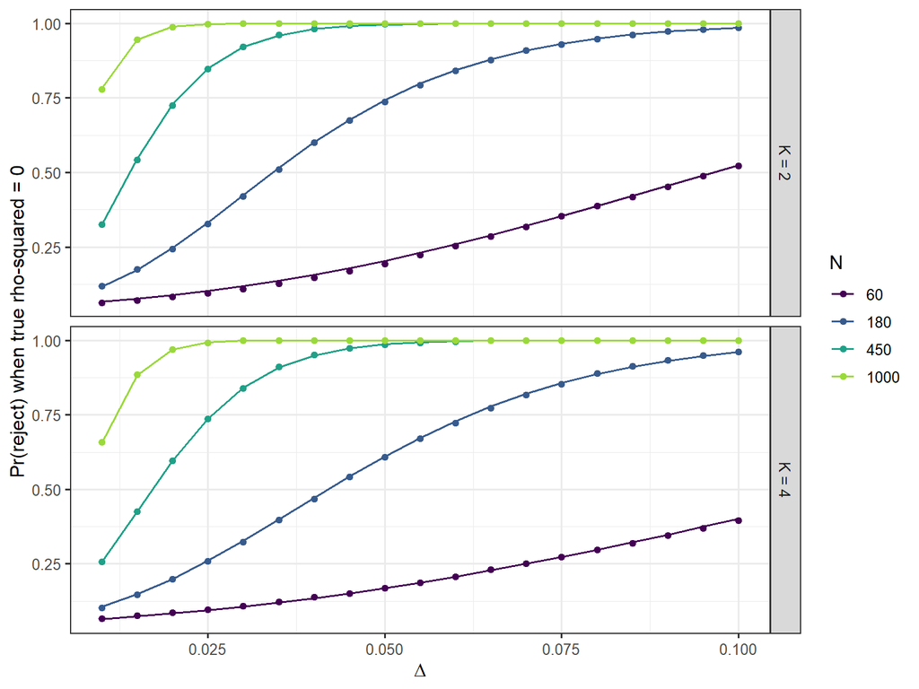

Figure 3: Simulated rejection rate under a true null effect (points) against the analytic power function (lines). Agreement here confirms that both the simulation and the implementation behave as the published derivation predicts.

```r
null_res <- results |>
  filter(is_null) |>
  rowwise() |>
  mutate(analytic = power_CL(Delta, K, N)) |>
  ungroup()

ggplot(null_res, aes(x = Delta, colour = N_lab)) +
  geom_line(aes(y = analytic)) +
  geom_point(aes(y = pr_reject), size = 1.6) +
  facet_grid(K_lab ~ .) +
  scale_colour_viridis_d(end = 0.85) +
  labs(x = expression(Delta), y = "Pr(reject) when true rho-squared = 0",
       colour = "N")
```

```r
# Exact binomial test of each simulated rate against its analytic value. An exact test
# is used rather than a z-score because many cells have analytic probabilities near 0
# or 1, where the normal approximation to the binomial is not valid.
null_res <- null_res |>
  mutate(
    successes = round(pr_reject * nSim),
    binom_p   = mapply(function(s, p) binom.test(s, nSim, p)$p.value,
                       successes, analytic),
    expected_count = nSim * analytic
  )

bonf <- 0.05 / nrow(null_res)

c(n_points          = nrow(null_res),
  max_abs_deviation = round(max(abs(null_res$pr_reject - null_res$analytic)), 4),
  min_binom_p       = signif(min(null_res$binom_p), 3),
  bonferroni_alpha  = signif(bonf, 3),
  n_below_bonf      = sum(null_res$binom_p < bonf))
```

```
         n_points max_abs_deviation       min_binom_p  bonferroni_alpha
         1.52e+02          1.03e-02          2.36e-03          3.29e-04
     n_below_bonf
         0.00e+00
```

No point deviates from the analytic value by more than exact-binomial sampling error would explain, after correcting for the number of comparisons. (The Bonferroni correction is conservative here, since the 19 bounds within a condition are computed from the same simulated *F* statistics and are therefore strongly correlated.)

As a secondary view, restricting to the cells where a normal approximation is actually valid — at least 10 expected successes and 10 expected failures — gives the usual standardized check:

```r
valid <- null_res |>
  filter(expected_count >= 10, expected_count <= nSim - 10) |>
  mutate(z = (pr_reject - analytic) / sqrt(analytic * (1 - analytic) / nSim))

c(n_valid_cells         = nrow(valid),
  max_abs_z             = round(max(abs(valid$z)), 2),
  n_exceeding_2z        = sum(abs(valid$z) > 2),
  expected_exceeding_2z = round(0.0455 * nrow(valid), 1))
```

```
        n_valid_cells             max_abs_z        n_exceeding_2z
               107.00                  3.02                  8.00
expected_exceeding_2z
                 4.90
```

The count of cells with $|z| > 2$ runs somewhat above the naive expectation. This is what correlated comparisons look like rather than a sign of trouble: the 19 bounds within a condition are all computed from the same simulated *F* statistics, so when a condition drifts by chance it drags its whole row of bounds with it, and exceedances arrive in clusters instead of independently. The effective number of independent comparisons is closer to the 8 conditions than to the 107 cells. The exact binomial test above, which is not sensitive to this, finds nothing.

**WarningA note on the cells excluded above**

Roughly a third of the grid has an analytic rejection probability below 0.001 or above 0.999. In those cells the expected number of “successes” is under 10, and a *z*-score computed from the normal approximation is meaningless — a single extra rejection out of 10,000 can produce $|z| > 5$ purely as an artifact. Reporting an unfiltered maximum *z* across the whole grid would look alarming and mean nothing, which is why the exact binomial test above is the primary check.

# Part 2: Beyond the designs Campbell & Lakens simulated

Everything above concerns the setting Campbell & Lakens actually simulated. In that setting TOSTER’s non-centrality parameter reduces exactly to the published one, so Part 1 verifies the *un*-extended procedure. This part tests the generalization itself: factorial, within-subjects, and mixed designs, where $df_1 + df_2 + 1 \neq N$.

## Where the published identity breaks

```r
gap <- data.frame(
  Design = c("Regression (K predictors)", "One-way between (J groups)",
             "Factorial between (p parameters)", "One-way RM (n subjects, k levels)",
             "Mixed: between effect", "Mixed: within effect"),
  df1 = c("K", "J-1", "varies", "k-1", "g-1", "k-1"),
  df2 = c("N-K-1", "N-J", "N-p", "(n-1)(k-1)", "g(n-1)", "g(n-1)(k-1)"),
  `df1+df2+1` = c("N", "N", "N-(p-df1-1)", "n(k-1)+1", "gn", "gn(k-1)+1"),
  `Total obs` = c("N", "N", "N", "nk", "gnk", "gnk"),
  check.names = FALSE
)
kable(gap, caption = "TOSTER's normalizer df1+df2+1 against the total number of observations. The two coincide only in the designs Campbell & Lakens simulated.")
```

TOSTER’s normalizer df1+df2+1 against the total number of observations. The two coincide only in the designs Campbell & Lakens simulated.

| Design | df1 | df2 | df1+df2+1 | Total obs |
| --- | --- | --- | --- | --- |
| Regression (K predictors) | K | N-K-1 | N | N |
| One-way between (J groups) | J-1 | N-J | N | N |
| Factorial between (p parameters) | varies | N-p | N-(p-df1-1) | N |
| One-way RM (n subjects, k levels) | k-1 | (n-1)(k-1) | n(k-1)+1 | nk |
| Mixed: between effect | g-1 | g(n-1) | gn | gnk |
| Mixed: within effect | k-1 | g(n-1)(k-1) | gn(k-1)+1 | gnk |

The gap is not a rounding error. For a one-way repeated-measures design, $df_1 + df_2 + 1 \approx n(k-1)$ while the data contain $nk$ observations, a ratio of $(k-1)/k$ that does **not** shrink as $n$ grows. Taken at face value that looks like a serious problem.

It is not, and the reason is the organising idea of this whole part:

**Important$df_1 + df_2 + 1$ is the effective sample size of the *error stratum**

$df_1 + df_2$ is the dimension of the contrast space in which the effect is tested. In a single-stratum design that space is the whole data set and $df_1 + df_2 + 1 = N$. In a repeated-measures design the within-subject test lives in the subject-centred contrast space of dimension $n(k-1)$, and in a mixed design the between-subjects test lives on the $gn$ subject means. TOSTER’s bound is therefore a variance ratio *within the stratum where the effect is tested* — which is precisely what “partial” means in partial $\eta^2$.

The mixed design settles this, because there the two readings point in opposite directions: the between-subjects effect has $df_1 + df_2 + 1 = gn$, the number of subjects, which is far **smaller** than $gnk$ but exactly right.

## Three calibration targets

Because the bound is a number on some scale, “is the Type I error controlled?” has no answer until the scale is fixed. Three candidates, all exact functions of the true non-centrality $\lambda$:

| Target | Formula | Reading |
| --- | --- | --- |
| $\Delta_{pop}$ | $\lambda/(\lambda + N_{total})$ | share of *total* variance |
| $\Delta_{tost}$ | $\lambda/(\lambda + df_1 + df_2 + 1)$ | what TOSTER’s inversion implies |
| $\Delta_{pes}$ | $\lambda/(\lambda + df_2)$ | limit of the reported `pes` statistic |

```r
targets_for <- function(lam, df1, df2, N_total) {
  c(Delta_pop  = lam / (lam + N_total),
    Delta_tost = lam / (lam + df1 + df2 + 1),
    Delta_pes  = lam / (lam + df2))
}
```

$\Delta_{tost}$ and $\Delta_{pes}$ differ only by $df_1 + 1$ in the denominator, so they agree to $O(1/n)$ in every design. $\Delta_{pop}$ is the odd one out whenever the design has more than one error stratum.

## The rejection rate in closed form

The test rejects when `pf(F, df1, df2, ncp = lambda_eq) < alpha`. Because `pf` is strictly increasing in `F`, this is exactly `F < qf(alpha, df1, df2, ncp = lambda_eq)`. So when the observed *F* really is non-central *F* with non-centrality $\lambda$, the rejection rate is available analytically — no simulation needed:

```r
rate_exact <- function(Delta, df1, df2, lam, alpha = 0.05) {
  pf(qf(alpha, df1, df2, ncp = Delta/(1-Delta)*(df1+df2+1)),
     df1, df2, ncp = lam)
}

# Evaluating a whole grid of bounds against stored F statistics, via critical values
sweep_delta <- function(Fstats, Deltavec, df1, df2, alpha = 0.05) {
  crit <- qf(alpha, df1, df2, ncp = Deltavec/(1-Deltavec)*(df1+df2+1))
  findInterval(crit, sort(Fstats)) / length(Fstats)
}
```

This generalizes `power_eq_f()`, which is the same quantity at $\lambda = 0$:

```r
chk <- expand.grid(D = c(0.02, 0.06, 0.14), df1 = c(1, 2, 3), df2 = c(20, 60))
chk$exact <- mapply(rate_exact, chk$D, chk$df1, chk$df2, 0)
chk$power_eq_f <- suppressMessages(mapply(
  function(D, a, b) power_eq_f(alpha = 0.05, df1 = a, df2 = b, eqbound = D)$power,
  chk$D, chk$df1, chk$df2))
c(comparisons = nrow(chk),
  max_abs_diff = max(abs(chk$exact - chk$power_eq_f)))
```

```
 comparisons max_abs_diff
 1.80000e+01  1.94289e-16
```

Simulation is still used below — the analytic rate assumes the *F* statistic really has the non-central distribution the theory says it does, which is exactly one of the things being tested. Where the two agree, that assumption holds.

## Design A: one-way within-subjects ANOVA

Model $Y_{ij} = \mu + \alpha_j + s_i + e_{ij}$ with $s_i \sim N(0, \sigma^2_s)$ and $e_{ij} \sim N(0, \sigma^2_e)$. The within-subject test is computed in the contrast space $Z = YC'$ where $C$ is any $(k-1) \times k$ orthonormal contrast matrix with $C\mathbf{1} = 0$; then $\lambda = n \sum_j \alpha_j^2 / \sigma^2_e$, $df_1 = k-1$ and $df_2 = (n-1)(k-1)$.

```r
helm_C <- function(k) t(qr.Q(qr(cbind(1, contr.helmert(k)))))[-1, , drop = FALSE]

# Contrast-space simulator. psi = variances of the contrast scores (all 1 under
# sphericity); mu_c = contrast means, placing the effect within the contrast space.
rm_sim <- function(n, k, lam, psi = NULL, mu_c = NULL, nSim = 10000) {
  df1 <- k - 1; df2 <- (n - 1) * (k - 1)
  if (is.null(psi))  psi  <- rep(1, df1)
  if (is.null(mu_c)) mu_c <- { v <- rep(0, df1); v[1] <- sqrt(lam / n); v }
  stopifnot(length(psi) == df1, length(mu_c) == df1)
  G  <- matrix(rnorm(n * df1 * nSim), nrow = n)   # cols: contrast fastest, rep slowest
  G  <- sweep(G, 2, rep(sqrt(psi), times = nSim), "*")
  G  <- sweep(G, 2, rep(mu_c,      times = nSim), "+")
  cm <- colMeans(G); css <- colSums(G^2) - n * cm^2
  SSA  <- n * colSums(matrix(cm^2, nrow = df1))
  SSAS <-     colSums(matrix(css,  nrow = df1))
  (SSA / df1) / (SSAS / df2)
}
```

**NoteThe intraclass correlation cannot matter here**

Because $C\mathbf{1} = 0$, the subject effect $s_i$ is annihilated by the contrast: $\Psi = C\Sigma C' = \sigma^2_e I$ under compound symmetry, whatever $\sigma^2_s$ is. The *F* statistic — and therefore the whole test — is invariant to the intraclass correlation. This is why ICC is not a factor in the grid below. The check must be run with a full $n \times k$ generator, since the contrast simulator is blind to ICC by construction and testing it there would be vacuous.

```r
set.seed(404)
icc_check <- sapply(c(0, 0.3, 0.6, 0.9), function(rho) {
  n <- 20; k <- 3; s2e <- 1; s2s <- rho/(1-rho)*s2e
  al <- c(-1, 0, 1); al <- al/sqrt(sum(al^2))*sqrt(3/n)
  lam <- n*sum(al^2)/s2e; df1 <- k-1; df2 <- (n-1)*(k-1)
  Fs <- replicate(20000, {
    Y <- matrix(rep(al, each=n), n, k) + matrix(rnorm(n, 0, sqrt(s2s)), n, k) +
         matrix(rnorm(n*k, 0, sqrt(s2e)), n, k)
    g <- mean(Y); SA <- n*sum((colMeans(Y)-g)^2); SS <- k*sum((rowMeans(Y)-g)^2)
    (SA/df1) / ((sum((Y-g)^2)-SA-SS)/df2) })
  D <- lam/(lam+df1+df2+1)
  mean(Fs < qf(0.05, df1, df2, ncp = D/(1-D)*(df1+df2+1)))
})
setNames(round(icc_check, 4), paste0("ICC=", c(0, 0.3, 0.6, 0.9)))
```

```
  ICC=0 ICC=0.3 ICC=0.6 ICC=0.9
 0.0498  0.0498  0.0496  0.0498
```

All four sit at nominal, as the algebra requires.

### Conditions and results

```r
set.seed(2026)
nSim2    <- 10000
Deltavec2 <- seq(0.005, 0.40, by = 0.005)

rm_grid <- expand.grid(k = c(2, 3, 4, 8), n = c(10, 20, 50, 100),
                       eta2p = c(0, 0.02, 0.06, 0.14))

rm_res <- do.call(rbind, lapply(seq_len(nrow(rm_grid)), function(i) {
  g <- rm_grid[i, ]
  df1 <- g$k - 1; df2 <- (g$n - 1)*(g$k - 1); Ntot <- g$n * g$k
  lam <- Ntot * g$eta2p / (1 - g$eta2p)      # population eta2p -> lambda
  Fs  <- rm_sim(g$n, g$k, lam, nSim = nSim2)
  tg  <- targets_for(lam, df1, df2, Ntot)
  data.frame(k = g$k, n = g$n, eta2p = g$eta2p, df1 = df1, df2 = df2,
             Ntot = Ntot, lam = lam,
             Delta_pop = tg[["Delta_pop"]], Delta_tost = tg[["Delta_tost"]],
             Delta_pes = tg[["Delta_pes"]],
             rate_pop  = mean(Fs < qf(.05, df1, df2, ncp = tg[["Delta_pop"]]/(1-tg[["Delta_pop"]])*(df1+df2+1))),
             rate_tost = mean(Fs < qf(.05, df1, df2, ncp = tg[["Delta_tost"]]/(1-tg[["Delta_tost"]])*(df1+df2+1))),
             rate_pes  = mean(Fs < qf(.05, df1, df2, ncp = tg[["Delta_pes"]]/(1-tg[["Delta_pes"]])*(df1+df2+1))),
             curve = I(list(sweep_delta(Fs, Deltavec2, df1, df2))))
}))
nrow(rm_res)
```

```
[1] 64
```

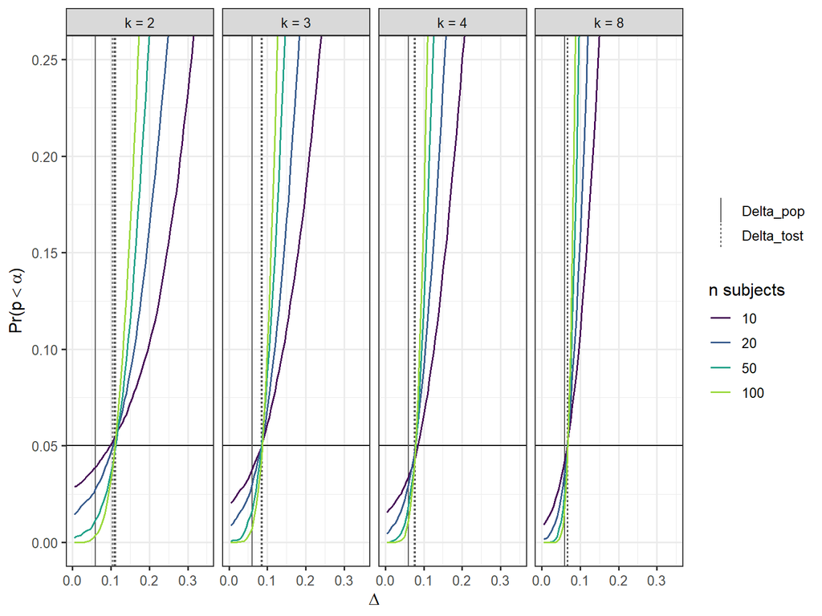

```r
rm_long <- do.call(rbind, lapply(which(rm_res$eta2p == 0.06), function(i)
  data.frame(k = rm_res$k[i], n = rm_res$n[i],
             Delta = Deltavec2, rate = rm_res$curve[[i]])))
rm_marks <- rm_res[rm_res$eta2p == 0.06, c("k","n","Delta_pop","Delta_tost")] |>
  pivot_longer(c(Delta_pop, Delta_tost), names_to = "target", values_to = "Delta")

ggplot(rm_long, aes(Delta, rate, colour = factor(n))) +
  geom_hline(yintercept = 0.05, linewidth = 0.4) +
  geom_vline(data = rm_marks, aes(xintercept = Delta, linetype = target),
             linewidth = 0.4, colour = "grey35") +
  geom_line(linewidth = 0.7) +
  facet_wrap(~ paste0("k = ", k), nrow = 1) +
  coord_cartesian(ylim = c(0, 0.25), xlim = c(0, 0.35)) +
  scale_colour_viridis_d(end = 0.85) +
  labs(x = expression(Delta), y = expression("Pr(" * p < alpha * ")"),
       colour = "n subjects", linetype = NULL)
```

```r
rm_b <- rm_res[rm_res$eta2p > 0, ]
rm_b |>
  group_by(k) |>
  summarise(conditions = n(),
            `mean rate @ Delta_pop`  = round(mean(rate_pop), 4),
            `mean rate @ Delta_tost` = round(mean(rate_tost), 4),
            `mean rate @ Delta_pes`  = round(mean(rate_pes), 4),
            `median Delta_tost/Delta_pop` = round(median(Delta_tost/Delta_pop), 3),
            .groups = "drop") |>
  kable(caption = "One-way repeated measures: rejection rate at each of the three calibration targets, averaged over n and effect size. Nominal alpha = 0.05.")
```

Table 2: One-way repeated measures: rejection rate at each of the three calibration targets, averaged over n and effect size. Nominal alpha = 0.05.

| k | conditions | mean rate @ Delta_pop | mean rate @ Delta_tost | mean rate @ Delta_pes | median Delta_tost/Delta_pop |
| --- | --- | --- | --- | --- | --- |
| 2 | 12 | 0.0219 | 0.0512 | 0.0580 | 1.798 |
| 3 | 12 | 0.0239 | 0.0505 | 0.0568 | 1.420 |
| 4 | 12 | 0.0256 | 0.0500 | 0.0567 | 1.285 |
| 8 | 12 | 0.0309 | 0.0500 | 0.0579 | 1.125 |

The verdict depends entirely on which scale the bound is read on, and the ratio $\Delta_{tost}/\Delta_{pop}$ approaches $k/(k-1)$ — so the discrepancy is **largest at $k = 2$**, not at large $k$.

- On $\Delta_{tost}$, the rate is nominal in every cell. The procedure controls its size.
- On $\Delta_{pes}$ it is mildly liberal in small samples, which is the ordinary upward bias of $\eta^2_p$ rather than a fault in the bound.
- On $\Delta_{pop}$ it is severely conservative, and *increasingly* so as $n$ grows.

That last point is worth stating plainly, since it is the practical trap: a bound reasoned about as “this factor explains less than 5% of the variance in my data” is not the bound the function applies. `equ_anova()` works on the partial scale, where subject variance is excluded from the denominator.

## Design B: factorial between-subjects ANOVA

For a balanced $a \times b$ design with $m$ per cell, the cell means and the error sum of squares are independent and jointly sufficient, so there is no need to generate $N$ observations per replication.

```r
fac_sim <- function(a, b, m, eta2p = c(A = 0, B = 0, AB = 0),
                    sigma2 = 1, nSim = 10000) {
  N <- a*b*m; dfE <- N - a*b
  sc <- function(len, ss) { v <- seq_len(len) - (len+1)/2; v/sqrt(sum(v^2))*sqrt(ss) }
  # balanced design => effects orthogonal => all three targets can be set at once
  alpha_i <- sc(a, a * eta2p[["A"]] /(1 - eta2p[["A"]]))
  beta_j  <- sc(b, b * eta2p[["B"]] /(1 - eta2p[["B"]]))
  G0 <- outer(sc(a, 1), sc(b, 1)); G0 <- G0 - outer(rowMeans(G0), colMeans(G0), "+") + mean(G0)
  gam <- if (eta2p[["AB"]] > 0) G0/sqrt(sum(G0^2))*sqrt(a*b*eta2p[["AB"]]/(1-eta2p[["AB"]])) else G0*0
  M  <- outer(alpha_i, beta_j, "+") + gam
  CM <- as.vector(M) + matrix(rnorm(a*b*nSim, 0, sqrt(sigma2/m)), nrow = a*b)
  Ka <- model.matrix(~ 0 + factor(rep(1:a, times = b)))
  Kb <- model.matrix(~ 0 + factor(rep(1:b, each  = a)))
  rA <- crossprod(Ka, CM)/b; rB <- crossprod(Kb, CM)/a; g <- colMeans(CM)
  SSA <- m*b*colSums(sweep(rA, 2, g)^2)
  SSB <- m*a*colSums(sweep(rB, 2, g)^2)
  Rr  <- CM - Ka %*% rA - Kb %*% rB + rep(g, each = a*b)
  SSAB <- m*colSums(Rr^2)
  MSE <- rchisq(nSim, dfE) * sigma2 / dfE
  list(A = (SSA/(a-1))/MSE, B = (SSB/(b-1))/MSE, AB = (SSAB/((a-1)*(b-1)))/MSE,
       lam = c(A = m*b*sum(alpha_i^2)/sigma2, B = m*a*sum(beta_j^2)/sigma2,
               AB = m*sum(gam^2)/sigma2),
       df1 = c(A = a-1, B = b-1, AB = (a-1)*(b-1)), dfE = dfE, N = N)
}
```

```r
set.seed(515)
fac_grid <- expand.grid(design = c("2x2","2x3","3x4"), m = c(5, 10, 25, 100),
                        eta2p = c(0.02, 0.06, 0.14), stringsAsFactors = FALSE)
fac_res <- do.call(rbind, lapply(seq_len(nrow(fac_grid)), function(i) {
  gg <- fac_grid[i, ]; ab <- as.integer(strsplit(gg$design, "x")[[1]])
  s <- fac_sim(ab[1], ab[2], gg$m,
               c(A = gg$eta2p, B = gg$eta2p, AB = gg$eta2p), nSim = nSim2)
  do.call(rbind, lapply(c("A","B","AB"), function(e) {
    df1 <- s$df1[[e]]; lam <- s$lam[[e]]
    tg <- targets_for(lam, df1, s$dfE, s$N)
    rt <- function(D) mean(s[[e]] < qf(.05, df1, s$dfE, ncp = D/(1-D)*(df1+s$dfE+1)))
    data.frame(design = gg$design, m = gg$m, effect = e, eta2p = gg$eta2p,
               df1 = df1, df2 = s$dfE, N = s$N, eff_N = df1 + s$dfE + 1,
               rate_pop = rt(tg[["Delta_pop"]]), rate_tost = rt(tg[["Delta_tost"]]),
               rate_pes = rt(tg[["Delta_pes"]]))
  }))
}))
nrow(fac_res)
```

```
[1] 108
```

```r
fac_res |>
  group_by(design, effect) |>
  summarise(`rate @ pop` = round(mean(rate_pop), 4),
            `rate @ tost` = round(mean(rate_tost), 4),
            `rate @ pes` = round(mean(rate_pes), 4),
            `eff_N vs N` = paste0(min(eff_N - N), " to ", max(eff_N - N)),
            .groups = "drop") |>
  kable(caption = "Factorial between-subjects designs, averaged over cell size and effect size. Here df1+df2+1 falls short of N by only (p - df1 - 1), so all three calibrations nearly agree.")
```

Table 3: Factorial between-subjects designs, averaged over cell size and effect size. Here df1+df2+1 falls short of N by only (p - df1 - 1), so all three calibrations nearly agree.

| design | effect | rate @ pop | rate @ tost | rate @ pes | eff_N vs N |
| --- | --- | --- | --- | --- | --- |
| 2x2 | A | 0.0480 | 0.0508 | 0.0542 | -2 to -2 |
| 2x2 | AB | 0.0477 | 0.0505 | 0.0538 | -2 to -2 |
| 2x2 | B | 0.0485 | 0.0510 | 0.0543 | -2 to -2 |
| 2x3 | A | 0.0455 | 0.0500 | 0.0529 | -4 to -4 |
| 2x3 | AB | 0.0456 | 0.0490 | 0.0531 | -3 to -3 |
| 2x3 | B | 0.0475 | 0.0510 | 0.0555 | -3 to -3 |
| 3x4 | A | 0.0414 | 0.0489 | 0.0522 | -9 to -9 |
| 3x4 | AB | 0.0458 | 0.0499 | 0.0570 | -5 to -5 |
| 3x4 | B | 0.0427 | 0.0496 | 0.0541 | -8 to -8 |

In a single-stratum factorial the gap is $p - df_1 - 1$ observations out of $N$, so all three targets nearly coincide and the distinction that dominated Design A almost vanishes. The rate is at or just below nominal throughout: mildly conservative, $O(1/N)$.

## Design C: mixed designs

This is the case that decides between the two readings, because the between-subjects effect is tested on the $gn$ subject means while the data contain $gnk$ observations.

```r
set.seed(626)
mix_grid <- expand.grid(g = c(2, 3), n = c(15, 30), k = c(3, 4), eta2p = c(0.06))
mix_res <- do.call(rbind, lapply(seq_len(nrow(mix_grid)), function(i) {
  q <- mix_grid[i, ]; ns <- q$g * q$n; Ntot <- ns * q$k
  # between stratum: one-way ANOVA on subject means, tau2 = s2s + s2e/k
  s2s <- 1; s2e <- 1; tau2 <- s2s + s2e/q$k
  df1 <- q$g - 1; df2 <- q$g * (q$n - 1)
  lam <- (df1 + df2 + 1) * q$eta2p/(1 - q$eta2p)   # target on the subject-mean scale
  gam <- { v <- seq_len(q$g) - (q$g+1)/2; v/sqrt(sum(v^2))*sqrt(lam*tau2/q$n) }
  sm <- rep(gam, each = q$n) + matrix(rnorm(ns*nSim2, 0, sqrt(tau2)), ns, nSim2)
  grp <- rep(seq_len(q$g), each = q$n)
  gm <- rowsum(sm, grp)/q$n; gmn <- colMeans(sm)
  SSb <- q$n * colSums(sweep(gm, 2, gmn)^2)
  SSw <- colSums((sm - gm[grp, , drop = FALSE])^2)
  Fb  <- (SSb/df1)/(SSw/df2)
  tg <- targets_for(lam, df1, df2, Ntot)
  rt <- function(D) mean(Fb < qf(.05, df1, df2, ncp = D/(1-D)*(df1+df2+1)))
  data.frame(g = q$g, n = q$n, k = q$k, n_subj = ns, N_total = Ntot,
             eff_N = df1 + df2 + 1,
             Delta_pop = round(tg[["Delta_pop"]], 4),
             Delta_tost = round(tg[["Delta_tost"]], 4),
             rate_pop = rt(tg[["Delta_pop"]]), rate_tost = rt(tg[["Delta_tost"]]))
}))
kable(mix_res, caption = "Mixed design, between-subjects effect. eff_N equals the number of subjects exactly, and it is the total-observation reading that is wrong -- here in the opposite direction from Design A.")
```

Mixed design, between-subjects effect. eff_N equals the number of subjects exactly, and it is the total-observation reading that is wrong – here in the opposite direction from Design A.

| g | n | k | n_subj | N_total | eff_N | Delta_pop | Delta_tost | rate_pop | rate_tost |
| --- | --- | --- | --- | --- | --- | --- | --- | --- | --- |
| 2 | 15 | 3 | 30 | 90 | 30 | 0.0208 | 0.06 | 0.0259 | 0.0512 |
| 3 | 15 | 3 | 45 | 135 | 45 | 0.0208 | 0.06 | 0.0191 | 0.0493 |
| 2 | 30 | 3 | 60 | 180 | 60 | 0.0208 | 0.06 | 0.0136 | 0.0502 |
| 3 | 30 | 3 | 90 | 270 | 90 | 0.0208 | 0.06 | 0.0068 | 0.0478 |
| 2 | 15 | 4 | 30 | 120 | 30 | 0.0157 | 0.06 | 0.0262 | 0.0529 |
| 3 | 15 | 4 | 45 | 180 | 45 | 0.0157 | 0.06 | 0.0190 | 0.0540 |
| 2 | 30 | 4 | 60 | 240 | 60 | 0.0157 | 0.06 | 0.0114 | 0.0487 |
| 3 | 30 | 4 | 90 | 360 | 90 | 0.0157 | 0.06 | 0.0060 | 0.0496 |

`eff_N` equals `n_subj` in every row. The between-subjects effect *is* a one-way ANOVA on the subject means, and TOSTER’s normalizer recovers exactly that. Reading the bound against total observations is wrong by a factor of $k$ — and note the direction has flipped relative to Design A. No single fixed relationship to $N$ could be right in both places, which is what makes $df_1 + df_2 + 1$ the correct general answer rather than a convenient approximation.

## Caveat: sphericity corrections are not applied

Everything above assumed compound symmetry. When sphericity fails, `equ_anova()` has a genuine limitation: it reads the uncorrected univariate degrees of freedom from the `Anova.mlm` object and never applies a Greenhouse-Geisser or Huynh-Feldt correction. The correction machinery in `R/anova_summary.R` is commented out, and `add_corrected_df()` does not exist in the package. Fitting with `afex::aov_car(..., anova_table = list(correction = "GG"))` therefore has **no effect** on the equivalence *p*-value.

To quantify the cost, write $\Psi = C\Sigma C'$ for the covariance of the contrast scores and use Box’s $\epsilon = (\sum \psi_i)^2 / \big[(k-1)\sum \psi_i^2\big]$. Holding $\overline{\psi} = 1$ keeps the nominal non-centrality — and so the nominal boundary — fixed while $\epsilon$ varies, so any change in size is attributable to non-sphericity alone.

```r
eps_of <- function(psi) sum(psi)^2 / (length(psi) * sum(psi^2))
psi_for_eps <- function(k, target) {
  if (isTRUE(all.equal(target, 1))) return(rep(1, k - 1))
  stopifnot(target > 1/(k-1))
  cc <- uniroot(function(cc) eps_of(c(cc, rep(1, k-2))) - target, c(1, 1e6))$root
  p <- c(cc, rep(1, k-2)); p * (k-1) / sum(p)     # rescale to mean 1
}
```

Under a violation there is no single $\lambda$, because $SS_A$ becomes a weighted mix of non-central chi-squares. Where the effect sits in the contrast space therefore matters, so it enters as an explicit factor.

```r
set.seed(737)
sph <- expand.grid(k = c(4, 8), n = c(15, 30, 60), eps = c(1, 0.9, 0.75, 0.6, 0.5),
                   placement = c("high-variance", "low-variance", "uniform"),
                   eta2p = 0.06, stringsAsFactors = FALSE)
sph_res <- do.call(rbind, lapply(seq_len(nrow(sph)), function(i) {
  s <- sph[i, ]; df1 <- s$k - 1; df2 <- (s$n - 1)*(s$k - 1)
  lam <- (df1 + df2 + 1) * s$eta2p/(1 - s$eta2p)
  D   <- lam/(lam + df1 + df2 + 1)
  psi <- psi_for_eps(s$k, s$eps)
  v <- switch(s$placement, `high-variance` = c(1, rep(0, df1-1)),
              `low-variance` = c(rep(0, df1-1), 1), uniform = rep(1, df1))
  mu <- v/sqrt(sum(v^2))*sqrt(lam/s$n)
  Fs <- rm_sim(s$n, s$k, lam, psi = psi, mu_c = mu, nSim = nSim2)
  cbind(s, size = mean(Fs < qf(.05, df1, df2, ncp = D/(1-D)*(df1+df2+1))))
}))
```

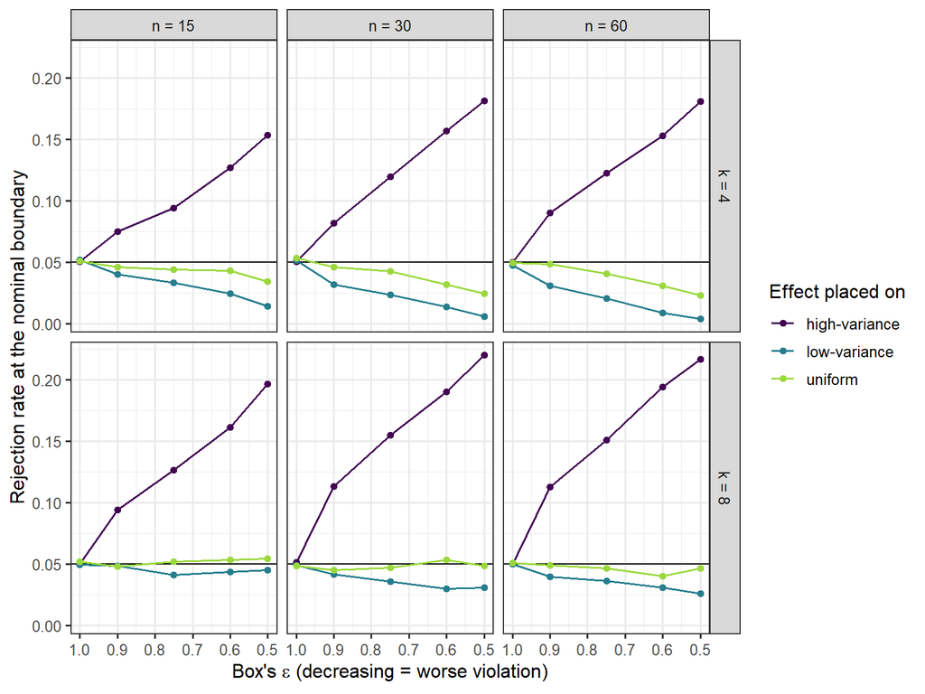

Figure 5: Size of the equivalence test at its nominal boundary as sphericity degrades. Epsilon = 1 is the built-in control and returns nominal size. The direction and severity of the failure depend on where the effect sits in the contrast space.

```r
ggplot(sph_res, aes(eps, size, colour = placement)) +
  geom_hline(yintercept = 0.05, linewidth = 0.4) +
  geom_line(linewidth = 0.7) + geom_point(size = 1.5) +
  facet_grid(paste0("k = ", k) ~ paste0("n = ", n)) +
  scale_x_reverse() + scale_colour_viridis_d(end = 0.85) +
  labs(x = expression("Box's " * epsilon * " (decreasing = worse violation)"),
       y = "Rejection rate at the nominal boundary", colour = "Effect placed on")
```

```r
sph_res |>
  group_by(eps, placement) |>
  summarise(size = round(mean(size), 4), .groups = "drop") |>
  pivot_wider(names_from = placement, values_from = size) |>
  kable(caption = "Size at the nominal boundary by Box's epsilon, averaged over k and n. Nominal alpha = 0.05.")
```

Table 4: Size at the nominal boundary by Box’s epsilon, averaged over k and n. Nominal alpha = 0.05.

| eps | high-variance | low-variance | uniform |
| --- | --- | --- | --- |
| 0.50 | 0.1916 | 0.0209 | 0.0384 |
| 0.60 | 0.1639 | 0.0253 | 0.0421 |
| 0.75 | 0.1282 | 0.0319 | 0.0455 |
| 0.90 | 0.0945 | 0.0387 | 0.0471 |
| 1.00 | 0.0504 | 0.0500 | 0.0508 |

The $\epsilon = 1$ row returns nominal size, confirming the construction. Away from it the test is badly miscalibrated — inflated by several times $\alpha$ when the effect loads on a high-variance contrast, and driven to near zero when it loads on a low-variance one. This is a real limitation, and it is the only genuine failure anywhere in this document.

**WarningPractical implication**

For repeated-measures designs with $k > 2$, check sphericity on the fitted model before trusting `equ_anova()`, and treat a Mauchly test or an $\hat{\epsilon}$ well below 1 as a reason not to rely on the equivalence *p*-value. Note this is a limitation of the current implementation, not of the underlying method: a corrected-$df$ version is possible and would slot into `R/anova_summary.R`. With $k = 2$ there is only one contrast and sphericity is not an issue.

## Pipeline check: does `equ_anova()` extract the right degrees of freedom?

Everything above tests the mathematics on *F* statistics computed directly. It does not test how TOSTER pulls $df_1$ and $df_2$ out of a fitted model object — which is where a practical bug would live. This fits real datasets with `stats::aov` and `afex::aov_car` and compares against the closed-form path.

```r
suppressMessages(library(afex))
set.seed(848)
eqb <- 0.075
pipe <- do.call(rbind, lapply(1:4, function(rep_i) {
  out <- list()
  # (a) one-way RM, k = 4
  n <- 12; k <- 4
  Y <- matrix(rnorm(n*k), n, k) + rep(c(0, .4, .2, .7), each = n) + rnorm(n)
  d <- data.frame(y = as.vector(Y), id = factor(rep(1:n, k)),
                  cond = factor(rep(1:k, each = n)))
  ea <- suppressMessages(equ_anova(aov(y ~ cond + Error(id/cond), data = d), eqbound = eqb))
  ea$effect <- trimws(ea$effect)                       # aov path pads names with spaces
  r <- ea[ea$effect == "cond", ]
  gmn <- mean(Y); SA <- n*sum((colMeans(Y)-gmn)^2); SS <- k*sum((rowMeans(Y)-gmn)^2)
  Ff <- (SA/(k-1))/((sum((Y-gmn)^2)-SA-SS)/((n-1)*(k-1)))
  out[[1]] <- data.frame(design = "one-way RM", effect = "cond",
    d_df1 = r$df1-(k-1), d_df2 = r$df2-(n-1)*(k-1), d_F = r$F.value-Ff,
    d_p = r$p.equ - equ_ftest(Ff, k-1, (n-1)*(k-1), eqbound = eqb)$p.value)
  # (b) 2x3 between-subjects
  a <- 2; b <- 3; m <- 8
  dd <- expand.grid(rep = 1:m, A = factor(1:a), B = factor(1:b))
  dd$y <- rnorm(nrow(dd)) + as.numeric(dd$A)*.5 + as.numeric(dd$B)*.3
  an <- anova(lm(y ~ A*B, data = dd))
  ea2 <- suppressMessages(equ_anova(aov(y ~ A*B, data = dd), eqbound = eqb))
  ea2$effect <- trimws(ea2$effect)
  for (e in c("A","B","A:B")) {
    rr <- ea2[ea2$effect == e, ]; Fa <- an[e, "F value"]; d2 <- an["Residuals","Df"]
    out[[length(out)+1]] <- data.frame(design = "2x3 between", effect = e,
      d_df1 = rr$df1-an[e,"Df"], d_df2 = rr$df2-d2, d_F = rr$F.value-Fa,
      d_p = rr$p.equ - equ_ftest(Fa, an[e,"Df"], d2, eqbound = eqb)$p.value)
  }
  do.call(rbind, out)
}))
pipe |> group_by(design, effect) |>
  summarise(across(starts_with("d_"), ~ max(abs(.x))), .groups = "drop") |>
  kable(caption = "Maximum absolute discrepancy between equ_anova() and the closed-form path, over 4 simulated datasets per design. Zero everywhere means df extraction is correct.")
```

Maximum absolute discrepancy between equ_anova() and the closed-form path, over 4 simulated datasets per design. Zero everywhere means df extraction is correct.

| design | effect | d_df1 | d_df2 | d_F | d_p |
| --- | --- | --- | --- | --- | --- |
| 2x3 between | A | 0 | 0 | 0 | 0 |
| 2x3 between | A:B | 0 | 0 | 0 | 0 |
| 2x3 between | B | 0 | 0 | 0 | 0 |
| one-way RM | cond | 0 | 0 | 0 | 0 |

Two wrinkles worth recording for anyone doing this comparison: the `aov`/`aovlist` path returns effect names **padded with trailing spaces** (`"cond "`), because `reformat_aov_summary()` never calls the `remove_empty_space()` helper defined alongside it, so any join on `effect` needs `trimws()`; and the `afex_aov` / `Anova.mlm` path emits an extra `(Intercept)` row that the `aov` path does not.

## What the extension shows

```r
rbind(
  data.frame(Design = "One-way RM",       n_cells = sum(rm_res$eta2p > 0),
             rate_at_Delta_tost = round(mean(rm_res$rate_tost[rm_res$eta2p > 0]), 4)),
  data.frame(Design = "Factorial between", n_cells = nrow(fac_res),
             rate_at_Delta_tost = round(mean(fac_res$rate_tost), 4)),
  data.frame(Design = "Mixed (between)",   n_cells = nrow(mix_res),
             rate_at_Delta_tost = round(mean(mix_res$rate_tost), 4))
) |> kable(caption = "Type I error at the boundary, on TOSTER's own scale, across every design tested. Nominal alpha = 0.05.")
```

Type I error at the boundary, on TOSTER’s own scale, across every design tested. Nominal alpha = 0.05.

| Design | n_cells | rate_at_Delta_tost |
| --- | --- | --- |
| One-way RM | 48 | 0.0504 |
| Factorial between | 108 | 0.0501 |
| Mixed (between) | 8 | 0.0505 |

1. **The generalization is sound.** On its own scale the procedure holds its size in every design tested — one-way repeated measures, factorial between-subjects, and the between-subjects effect of a mixed design — none of which Campbell & Lakens simulated.
2. **$df_1 + df_2 + 1$ is the effective sample size of the error stratum**, not an approximation to total N. The mixed design proves this, since there the correct normalizer is *smaller* than total N while in the factorial case it is nearly equal.
3. **The bound is on the partial scale, and in repeated-measures designs that is not the share of total variance.** Calibrating a bound as “less than 5% of the variance in my data” and passing it to `equ_anova()` produces a much more conservative test than intended, increasingly so as n grows. This is an interpretation trap, not a bug.
4. **Sphericity is the real limitation.** Corrections are silently ignored, and the resulting size distortion is large and can run in either direction.

## Notes on the published supplementary code

A few observations for anyone attempting to run `disregard_simulation_study_2.R` directly. None of these affect the paper’s conclusions.

1. **A hard-coded path breaks the script mid-run.** Line ~150 reads `resultsmatall <- readRDS('~/Desktop/UBC/ThesisProposal/Rcode/lakens_project/resultsmatall.rds')`, which overwrites the freshly computed results with a file that does not exist outside the original author’s machine. The script cannot be run end-to-end as published.
2. **The true $\rho^2$ is obtained by Monte Carlo over a 32-million-row design matrix** (`rep(basematrix$X1, 1000000)`), which is memory-hungry and unnecessary — the quantity is available in closed form, as shown above.
3. **The design matrix is mildly unbalanced.** `X[1:N, ]` truncates a repeating 16-row block, and no simulated $N$ is a multiple of 16. The effect is small but it does mean the realized $\rho^2$ differs slightly from the population value for $K = 4$.
4. **True $\rho^2$ values are post-hoc binned** by a series of range-based `if`-style reassignments before plotting, which smooths over the imbalance in (3) rather than modelling it.
5. **`qplot()` is used for plotting**, which is deprecated in current ggplot2 and now emits a warning.
6. **The null condition is flagged with `sigma2 == 1.0001`** as a sentinel value rather than an explicit indicator, which is easy to misread.

## Conclusion

TOSTER’s implementation is numerically identical to the published procedure in the setting Campbell & Lakens evaluated, and reproducing their simulation recovers the operating characteristics the paper reports: nominal Type I error at the boundary of the null, conservatism inside it, and power that matches the analytic derivation under a true null effect.

Beyond that setting, the generalization that TOSTER adds — substituting $df_1 + df_2 + 1$ for the total sample size in the non-centrality parameter — controls Type I error in every design tested, including the repeated-measures and mixed designs where that substitution changes the answer materially. The substitution is not an approximation to $N$; it is the effective sample size of the stratum in which the effect is tested, which is what makes the resulting bound a *partial* variance ratio.

Two things follow for the manuscript. The first is an interpretation point that deserves stating wherever the ANOVA bound is discussed: in repeated-measures designs a bound on partial $\eta^2$ is not a bound on the share of total variance, and the two can differ by a factor approaching $k/(k-1)$. The second is a genuine limitation: sphericity corrections are not applied, and when sphericity fails the size distortion is large and can run in either direction. That is worth fixing in the package rather than only documenting.

## References

Campbell, H., & Lakens, D. (2021). Can we disregard the whole model? Omnibus non-inferiority testing for $R^2$ in multi-variable linear regression and in ANOVA. *British Journal of Mathematical and Statistical Psychology*, 74(1), e12201. https://doi.org/10.1111/bmsp.12201